# World of Warcraft Classic: Warrior

Jackson Banner

25 Feb 2025

### Problem Statement

In the video game World of Warcraft (WoW) Classic, should a damage-per-second (dps) Warrior focus on building strength or agility? The assumption has always been strength in this scenario, but let’s look at the data and see what it says.

### Project Data

The full data sheets can be found [here](https://docs.google.com/spreadsheets/d/1aHx04N5XVxYufGXE90H2nfaWWa_PmjIkcnFwAPI9cJM/edit?gid=0#gid=0) and is referenced throughout this document.

### Source and Baseline

I used [WoWHead](https://www.wowhead.com/classic/guide/classic-wow-stats-and-attributes-overview) to gather the specifics of how each stat in WoW Classic interacts.

Here are the relevant interactions for this project:

- 14 attack power increases base melee dps by 1
- 1 strength for Warriors = 2 attack power (0.14 dps), 0% critical strike chance
- 20 agility for Warriors = 0 attack power, 1% critical strike chance
- at 300 weapon skill (level 60), Warriors will have a base of 12% critical strike chance before adding any critical strike chance from agility

While strength will contribute directly to attack power and dps, agility increases critical strike chance which doubles the damage dealt by a strike when they occur.

A level 60 Warrior will have around 120 strength and 80 agility (varies by race) before adding any contribution from armor etc., so that’s where I chose to start each stat for this evaluation.

### How Does Critical Strike Chance Affect DPS?

To verify dps increase based on critical strike chance, dps was evaluated on a 60 second time interval. For example:

If damage was dealt for 60 seconds with a 10% critical strike chance, it could be approximated that 10% of the 60 seconds were critical damage (deals double damage) and therefore increases the dps accordingly. Therefore, it can be estimated that the amount of critical strike chance will approximately increase damage by the same percent. See the below table for details or check out the data used for this projected that is referenced at the beginning of the document under the “Project Data”.

Here’s a breakdown of the 1st row in the below table to help show the thought process:

- 17 dps is 1020 damage over 60 seconds
- with a 10% critical chance, 10% of 60 seconds will be double damage, which is 6 seconds
- 6 seconds of critical damage (double damage) results in 102 extra damage
- the total damage is now 1122, which is a 10% increase in damage dealt

| dps | 60sec of dps | crit chance | time critting | crit dam | total dam | dam increase | new dps over 60s | % of original dps |
| --- | --- | --- | --- | --- | --- | --- | --- | --- |
| 17 | 1020 | 10% | 6 | 102 | 1122 | 10.00% | 18.7 | 1.7 |
| 17 | 1020 | 20% | 12 | 204 | 1224 | 20.00% | 20.4 | 3.4 |
| 17 | 1020 | 30% | 18 | 306 | 1326 | 30.00% | 22.1 | 5.1 |
| 17 | 1020 | 40% | 24 | 408 | 1428 | 40.00% | 23.8 | 6.8 |
| 17 | 1020 | 50% | 30 | 510 | 1530 | 50.00% | 25.5 | 8.5 |
| 17 | 1020 | 60% | 36 | 612 | 1632 | 60.00% | 27.2 | 10.2 |
| 17 | 1020 | 70% | 42 | 714 | 1734 | 70.00% | 28.9 | 11.9 |
| 17 | 1020 | 80% | 48 | 816 | 1836 | 80.00% | 30.6 | 13.6 |
| 17 | 1020 | 90% | 54 | 918 | 1938 | 90.00% | 32.3 | 15.3 |
| 17 | 1020 | 100% | 60 | 1020 | 2040 | 100.00% | 34 | 17 |

### Evaluations

Here are the scenarios that were evaluated:

- static strength and increasing agility (increments of 20)
- static agility and increasing strength (increments of 20)
- both increasing (increments of 20)

For the full data, see the link mentioned in the beginning of the document under “Project Data”. Below is each mentioned evaluation graphed together:

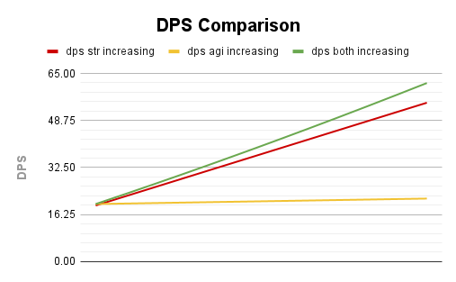

### Rates of Change

The following DPS rates of changes were found as they relate to strength and agility (rounded):

- static strength and increasing agility: 0.0086
- static agility and increasing strength: 0.1614

When strength is increasing (increments of 20), it has a significant higher impact on DPS than when agility is increasing.

### Gaps and Conclusion

This evaluation was a raw comparison utilizing an approximation of what a level 60 Warriors base stats would be. There was no consideration made for stats from abilities, talents, buffs, availability of each stat on gear that warriors can use, or dual wielding vs. using a 2 handed weapon.

Strength seemingly has a significantly higher impact on increasing DPS for Warriors than agility. While both increase DPS, per the rates of change found, **strength increased dps about 18 times more per 20 stat added compared to agility**.

### Feedback

Don’t hesitate to hit me up on Discord or Bluesky with any questions or adjustments I should make!